# 数据集

一共有三个数据文件：

- portfolio.json – 包括推送的 id 和每个推送的元数据（持续时间、种类等等）
- profile.json – 每个顾客的人口统计数据
- transcript.json – 交易、收到的推送、查看的推送和完成的推送的记录

以下是文件中每个变量的类型和解释 ：

**portfolio.json**

- id (string) – 推送的id
- offer_type (string) – 推送的种类，例如 BOGO、打折（discount）、信息（informational）
- difficulty (int) – 满足推送的要求所需的最少花费
- reward (int) – 满足推送的要求后给与的优惠
- duration (int) – 推送持续的时间，单位是天
- channels (list of strings)

**profile.json**

- age (int) – 顾客的年龄
- became_member_on (int) – 该顾客第一次注册app的时间
- gender (str) – 顾客的性别（注意除了表示男性的 M 和表示女性的 F 之外，还有表示其他的 O）
- id (str) – 顾客id
- income (float) – 顾客的收入

**transcript.json**

- event (str) – 记录的描述（比如交易记录、推送已收到、推送已阅）
- person (str) – 顾客id
- time (int) – 单位是小时，测试开始时计时。该数据从时间点 t=0 开始
- value - (dict of strings) – 推送的id 或者交易的数额

I. Data Exploration  
II.Data Cleaning  
III.Data Preprocessing  
3.1. Wrangle Data  
Method: Using a moduled class  
3.2. CHECK the wrangled data  
References

### Imports & Load in data

```python
import pandas as pd
import numpy as np
import math
import json

from time import time
from collections import defaultdict

import matplotlib.pyplot as plt
%matplotlib inline

# load in json files
portfolio = pd.read_json('data/portfolio.json', orient='records', lines=True)
profile = pd.read_json('data/profile.json', orient='records', lines=True)
transcript = pd.read_json('data/transcript.json', orient='records', lines=True)
```

# I. [Data Exploration](#Start)

## 1.1 Basic Information

| Method | Description |
| --- | --- |
| .head() | Index, Columns(Features) |
| .info() | NaN values, data size |
| .describe() | Statistik infomation |
| .unique() |  |
| .value_counts() |  |

```python
portfolio.head()
```

|  | reward | channels | difficulty | duration | offer_type | id |
| --- | --- | --- | --- | --- | --- | --- |
| 0 | 10 | [email, mobile, social] | 10 | 7 | bogo | ae264e3637204a6fb9bb56bc8210ddfd |
| 1 | 10 | [web, email, mobile, social] | 10 | 5 | bogo | 4d5c57ea9a6940dd891ad53e9dbe8da0 |
| 2 | 0 | [web, email, mobile] | 0 | 4 | informational | 3f207df678b143eea3cee63160fa8bed |
| 3 | 5 | [web, email, mobile] | 5 | 7 | bogo | 9b98b8c7a33c4b65b9aebfe6a799e6d9 |
| 4 | 5 | [web, email] | 20 | 10 | discount | 0b1e1539f2cc45b7b9fa7c272da2e1d7 |

```python
portfolio.info()
```

```
<class 'pandas.core.frame.DataFrame'>
RangeIndex: 10 entries, 0 to 9
Data columns (total 6 columns):
 #   Column      Non-Null Count  Dtype
---  ------      --------------  -----
 0   reward      10 non-null     int64
 1   channels    10 non-null     object
 2   difficulty  10 non-null     int64
 3   duration    10 non-null     int64
 4   offer_type  10 non-null     object
 5   id          10 non-null     object
dtypes: int64(3), object(3)
memory usage: 608.0+ bytes
```

```python
profile.head()
```

|  | gender | age | id | became_member_on | income |
| --- | --- | --- | --- | --- | --- |
| 0 | None | 118 | 68be06ca386d4c31939f3a4f0e3dd783 | 20170212 | NaN |
| 1 | F | 55 | 0610b486422d4921ae7d2bf64640c50b | 20170715 | 112000.0 |
| 2 | None | 118 | 38fe809add3b4fcf9315a9694bb96ff5 | 20180712 | NaN |
| 3 | F | 75 | 78afa995795e4d85b5d9ceeca43f5fef | 20170509 | 100000.0 |
| 4 | None | 118 | a03223e636434f42ac4c3df47e8bac43 | 20170804 | NaN |

```python
profile.info()
```

```
<class 'pandas.core.frame.DataFrame'>
RangeIndex: 17000 entries, 0 to 16999
Data columns (total 5 columns):
 #   Column            Non-Null Count  Dtype
---  ------            --------------  -----
 0   gender            14825 non-null  object
 1   age               17000 non-null  int64
 2   id                17000 non-null  object
 3   became_member_on  17000 non-null  int64
 4   income            14825 non-null  float64
dtypes: float64(1), int64(2), object(2)
memory usage: 664.2+ KB
```

**FOUND**:

- the type of 'became_member_on' is int64

```python
profile.describe()
```

|  | age | became_member_on | income |
| --- | --- | --- | --- |
| count | 17000.000000 | 1.700000e+04 | 14825.000000 |
| mean | 62.531412 | 2.016703e+07 | 65404.991568 |
| std | 26.738580 | 1.167750e+04 | 21598.299410 |
| min | 18.000000 | 2.013073e+07 | 30000.000000 |
| 25% | 45.000000 | 2.016053e+07 | 49000.000000 |
| 50% | 58.000000 | 2.017080e+07 | 64000.000000 |
| 75% | 73.000000 | 2.017123e+07 | 80000.000000 |
| max | 118.000000 | 2.018073e+07 | 120000.000000 |

**FOUND**:

- the max age is 118

```python
transcript.head()
```

|  | person | event | value | time |
| --- | --- | --- | --- | --- |
| 0 | 78afa995795e4d85b5d9ceeca43f5fef | offer received | {'offer id': '9b98b8c7a33c4b65b9aebfe6a799e6d9'} | 0 |
| 1 | a03223e636434f42ac4c3df47e8bac43 | offer received | {'offer id': '0b1e1539f2cc45b7b9fa7c272da2e1d7'} | 0 |
| 2 | e2127556f4f64592b11af22de27a7932 | offer received | {'offer id': '2906b810c7d4411798c6938adc9daaa5'} | 0 |
| 3 | 8ec6ce2a7e7949b1bf142def7d0e0586 | offer received | {'offer id': 'fafdcd668e3743c1bb461111dcafc2a4'} | 0 |
| 4 | 68617ca6246f4fbc85e91a2a49552598 | offer received | {'offer id': '4d5c57ea9a6940dd891ad53e9dbe8da0'} | 0 |

```python
transcript.info()
```

```
<class 'pandas.core.frame.DataFrame'>
RangeIndex: 306534 entries, 0 to 306533
Data columns (total 4 columns):
 #   Column  Non-Null Count   Dtype
---  ------  --------------   -----
 0   person  306534 non-null  object
 1   event   306534 non-null  object
 2   value   306534 non-null  object
 3   time    306534 non-null  int64
dtypes: int64(1), object(3)
memory usage: 9.4+ MB
```

# II. [Data Cleaning](#Start)

### 2.1. Demographic data: `profile`

#### `2.1.1.` Encode the column 'id'

(related to DataFrame `transcript`, `id` Encoding here should be done before .dropna())

1. Map 'id' to int number

```python
# create dict: {"original Code": int number}
id_mapping = defaultdict(int)

# original codes of ids
id_codes = profile['id'].unique().tolist()

num = 0
for id_code in id_codes:
    id_mapping[id_code] = num
    num += 1

def map_id_2_int(df, map_col, map_dict=id_mapping):
    '''Map 'id' from encode to int

    INPUT:
    - df(DataFrame): the target DataFrame in which 'id' to be mapped
    - map_col(str): the target col ('id') to be mapped
    - map_dict(dict): mapping dict {"original Code": int number}

    OUTPUT:
    - df(DataFrame): already mapped DataFrame
    '''
    df[map_col] = df[map_col].apply(lambda x: id_mapping[x])

    return df

# map 'id' in profile from encodes to int
profile_2_clean = map_id_2_int(profile, 'id')
profile_2_clean
```

|  | gender | age | id | became_member_on | income |
| --- | --- | --- | --- | --- | --- |
| 0 | None | 118 | 0 | 20170212 | NaN |
| 1 | F | 55 | 1 | 20170715 | 112000.0 |
| 2 | None | 118 | 2 | 20180712 | NaN |
| 3 | F | 75 | 3 | 20170509 | 100000.0 |
| 4 | None | 118 | 4 | 20170804 | NaN |
| ... | ... | ... | ... | ... | ... |
| 16995 | F | 45 | 16995 | 20180604 | 54000.0 |
| 16996 | M | 61 | 16996 | 20180713 | 72000.0 |
| 16997 | M | 49 | 16997 | 20170126 | 73000.0 |
| 16998 | F | 83 | 16998 | 20160307 | 50000.0 |
| 16999 | F | 62 | 16999 | 20170722 | 82000.0 |

17000 rows × 5 columns

#### `2.1.2.` NaNs

1. The NaNs in columns 'gender', 'income' and illegal age(age is 118) appear simultaneously.
   - It's fine to delete all the 2175 NaNs.

```python
# get the NaNs and illegal values in 'income', 'gender', 'age'
income_nan_Index = np.where(profile_2_clean.income.isnull())[0]  # index array of 'NaNs'
gender_nan_Index = np.where(profile_2_clean.gender.isnull())[0] # index array of 'Nones'
illegal_age_Index = np.where(profile_2_clean.age==118)

# the illegal values appear in the same index
print((income_nan_Index  == gender_nan_Index).all())
print((income_nan_Index  == illegal_age_Index).all())
```

```
True
True
```

```python
# drop all 2175 NaNs
profile_cleaned = profile_2_clean.dropna(axis=0)
profile_cleaned
```

|  | gender | age | id | became_member_on | income |
| --- | --- | --- | --- | --- | --- |
| 1 | F | 55 | 1 | 20170715 | 112000.0 |
| 3 | F | 75 | 3 | 20170509 | 100000.0 |
| 5 | M | 68 | 5 | 20180426 | 70000.0 |
| 8 | M | 65 | 8 | 20180209 | 53000.0 |
| 12 | M | 58 | 12 | 20171111 | 51000.0 |
| ... | ... | ... | ... | ... | ... |
| 16995 | F | 45 | 16995 | 20180604 | 54000.0 |
| 16996 | M | 61 | 16996 | 20180713 | 72000.0 |
| 16997 | M | 49 | 16997 | 20170126 | 73000.0 |
| 16998 | F | 83 | 16998 | 20160307 | 50000.0 |
| 16999 | F | 62 | 16999 | 20170722 | 82000.0 |

14825 rows × 5 columns

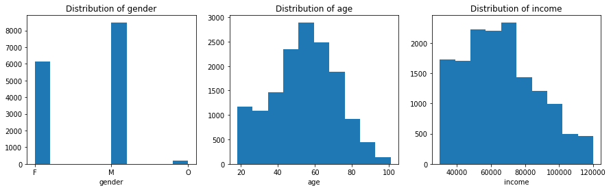

```python
# visualization
plt.figure(figsize=(15,4))

plt.subplot(1,3,1)
plt.hist(data=profile_cleaned, x='gender')
plt.title('Distribution of gender')
plt.xlabel('gender')

plt.subplot(1,3,2)
plt.hist(data=profile_cleaned, x='age')
plt.title('Distribution of age')
plt.xlabel('age')

plt.subplot(1,3,3)
plt.hist(data=profile_cleaned, x='income')
plt.title('Distribution of income')
plt.xlabel('income')

plt.show()
```

### 2.2. Promotion offer data: `portfolio`

#### `2.2.1.` Encode the column 'id'

1. Map 'id' to int number

```python
# create dict: {"original Code": int number}
offer_id_mapping = defaultdict()
offer_ids = portfolio['id']  # 10 ids codes

label = 0
for offer_id in offer_ids:
    offer_id_mapping[offer_id]=label
    label += 1

# for later use, we use .fillna(-1) to replace the NaN in 'offer_id'
offer_id_mapping[-1]=-1

offer_id_mapping
```

```
defaultdict(None,
            {'ae264e3637204a6fb9bb56bc8210ddfd': 0,
             '4d5c57ea9a6940dd891ad53e9dbe8da0': 1,
             '3f207df678b143eea3cee63160fa8bed': 2,
             '9b98b8c7a33c4b65b9aebfe6a799e6d9': 3,
             '0b1e1539f2cc45b7b9fa7c272da2e1d7': 4,
             '2298d6c36e964ae4a3e7e9706d1fb8c2': 5,
             'fafdcd668e3743c1bb461111dcafc2a4': 6,
             '5a8bc65990b245e5a138643cd4eb9837': 7,
             'f19421c1d4aa40978ebb69ca19b0e20d': 8,
             '2906b810c7d4411798c6938adc9daaa5': 9,
             -1: -1})
```

```python
portfolio_2_clean = portfolio.copy()

portfolio_2_clean['id'] = portfolio['id'].apply(lambda x: offer_id_mapping[x])
portfolio_2_clean
```

|  | reward | channels | difficulty | duration | offer_type | id |
| --- | --- | --- | --- | --- | --- | --- |
| 0 | 10 | [email, mobile, social] | 10 | 7 | bogo | 0 |
| 1 | 10 | [web, email, mobile, social] | 10 | 5 | bogo | 1 |
| 2 | 0 | [web, email, mobile] | 0 | 4 | informational | 2 |
| 3 | 5 | [web, email, mobile] | 5 | 7 | bogo | 3 |
| 4 | 5 | [web, email] | 20 | 10 | discount | 4 |
| 5 | 3 | [web, email, mobile, social] | 7 | 7 | discount | 5 |
| 6 | 2 | [web, email, mobile, social] | 10 | 10 | discount | 6 |
| 7 | 0 | [email, mobile, social] | 0 | 3 | informational | 7 |
| 8 | 5 | [web, email, mobile, social] | 5 | 5 | bogo | 8 |
| 9 | 2 | [web, email, mobile] | 10 | 7 | discount | 9 |

#### `2.2.2.` Column: 'channels'

1. Extract the list values into dependent columns  
   [References 1](https://intellipaat.com/community/32880/create-dummies-from-a-column-with-multiple-values-in-pandas)

```python
# Extract the list values in 'channels' into dependent columns
channels_2_df = portfolio_2_clean['channels'].str.join(sep='*').str.get_dummies(sep='*')
```

```python
# concat the extracted data from 'channels' with the original data, and delete 'channels'
portfolio_2_clean = pd.concat([portfolio_2_clean, channels_2_df], axis=1)
portfolio_cleaned= portfolio_2_clean.drop(labels='channels', axis=1)
portfolio_cleaned
```

|  | reward | difficulty | duration | offer_type | id | email | mobile | social | web |
| --- | --- | --- | --- | --- | --- | --- | --- | --- | --- |
| 0 | 10 | 10 | 7 | bogo | 0 | 1 | 1 | 1 | 0 |
| 1 | 10 | 10 | 5 | bogo | 1 | 1 | 1 | 1 | 1 |
| 2 | 0 | 0 | 4 | informational | 2 | 1 | 1 | 0 | 1 |
| 3 | 5 | 5 | 7 | bogo | 3 | 1 | 1 | 0 | 1 |
| 4 | 5 | 20 | 10 | discount | 4 | 1 | 0 | 0 | 1 |
| 5 | 3 | 7 | 7 | discount | 5 | 1 | 1 | 1 | 1 |
| 6 | 2 | 10 | 10 | discount | 6 | 1 | 1 | 1 | 1 |
| 7 | 0 | 0 | 3 | informational | 7 | 1 | 1 | 1 | 0 |
| 8 | 5 | 5 | 5 | bogo | 8 | 1 | 1 | 1 | 1 |
| 9 | 2 | 10 | 7 | discount | 9 | 1 | 1 | 0 | 1 |

### 2.3. Transactional records: `transcript`

#### `2.3.1.` Encode the column 'person'

1. map 'person' from encodes to int
2. update synchronous with dataset `profile_cleaned`(some person_id were dropped)

```python
# map 'person' from encodes to int
# there are the same number of unique person in datasets transcript and profile: 17,000
transcript_2_clean = map_id_2_int(transcript, 'person')
```

```python
# update synchronous to dataset profile_cleaned(some person_id were dropped)
valid_person = profile_cleaned.id.unique()
is_valid_person = transcript_2_clean.person.isin(valid_person)
transcript_2_clean = transcript_2_clean[is_valid_person]

print("number of unique person at begin is {}" .format(transcript.person.nunique()))
print("number of unique person synchronous updated is {}" .format(transcript_2_clean.person.nunique()))
transcript_2_clean # size (306534,4) at begin
```

```
number of unique person at begin is 17000
number of unique person synchronous updated is 14825
```

|  | person | event | value | time |
| --- | --- | --- | --- | --- |
| 0 | 3 | offer received | {'offer id': '9b98b8c7a33c4b65b9aebfe6a799e6d9'} | 0 |
| 2 | 5 | offer received | {'offer id': '2906b810c7d4411798c6938adc9daaa5'} | 0 |
| 5 | 8 | offer received | {'offer id': 'f19421c1d4aa40978ebb69ca19b0e20d'} | 0 |
| 7 | 12 | offer received | {'offer id': '3f207df678b143eea3cee63160fa8bed'} | 0 |
| 8 | 13 | offer received | {'offer id': '0b1e1539f2cc45b7b9fa7c272da2e1d7'} | 0 |
| ... | ... | ... | ... | ... |
| 306527 | 16949 | offer completed | {'offer_id': 'fafdcd668e3743c1bb461111dcafc2a4... | 714 |
| 306529 | 16959 | transaction | {'amount': 1.5899999999999999} | 714 |
| 306530 | 16964 | transaction | {'amount': 9.53} | 714 |
| 306531 | 16979 | transaction | {'amount': 3.61} | 714 |
| 306532 | 16987 | transaction | {'amount': 3.5300000000000002} | 714 |

272762 rows × 4 columns

#### `2.3.2.` Extract the column: 'value'

1. Extract the dict values into dependent columns according to the keys in dict

```python
# Extract the dict values into dependent columns
value_2_df = transcript_2_clean.value.apply(pd.Series)
```

```python
# Combine the data in 'offer id' into 'offer_id' (they belong to same data: but in different name)
is_offer_id_2b_updated = value_2_df['offer id'].notnull()
value_2_df['offer_id'] = np.where(is_offer_id_2b_updated, value_2_df['offer id'], value_2_df['offer_id'])
```

```python
# in original data: old 'offer_id' appears together with 'reward'
# !!!CHECK: number of updated 'offer_id' == (number of 'reward') +  (number of 'offer id')
print("The number of data in 'offer id' is {}"  .format(value_2_df['offer id'].count()))
print("The number of data in 'offer_id' is {}"  .format(value_2_df['reward'].count())) # before updated, bounded with 'reward'
print("The number of data in updated 'offer_id' is {} == {}+{}"  .format(value_2_df['offer_id'].count(), value_2_df['offer id'].count(), value_2_df['reward'].count()))
```

```
The number of data in 'offer id' is 116361
The number of data in 'offer_id' is 32444
The number of data in updated 'offer_id' is 148805 == 116361+32444
```

```python
# drop the column 'offer id'
value_2_df.drop(labels='offer id', axis=1, inplace=True)
value_2_df
```

|  | amount | offer_id | reward |
| --- | --- | --- | --- |
| 0 | NaN | 9b98b8c7a33c4b65b9aebfe6a799e6d9 | NaN |
| 2 | NaN | 2906b810c7d4411798c6938adc9daaa5 | NaN |
| 5 | NaN | f19421c1d4aa40978ebb69ca19b0e20d | NaN |
| 7 | NaN | 3f207df678b143eea3cee63160fa8bed | NaN |
| 8 | NaN | 0b1e1539f2cc45b7b9fa7c272da2e1d7 | NaN |
| ... | ... | ... | ... |
| 306527 | NaN | fafdcd668e3743c1bb461111dcafc2a4 | 2.0 |
| 306529 | 1.59 | NaN | NaN |
| 306530 | 9.53 | NaN | NaN |
| 306531 | 3.61 | NaN | NaN |
| 306532 | 3.53 | NaN | NaN |

272762 rows × 3 columns

```python
# concat value_2_df to the original dataset transcript
# drop the two useless columns 'value', 'reward'
transcript_2_clean = pd.concat([transcript_2_clean, value_2_df], axis=1).drop(labels=['value','reward'], axis=1)
```

#### `2.3.3.` NaNs

1. use .fillna()
   - in column 'amount': replace NaNs with `0`(float)
   - in column 'offer_id': replace NaNs with `-1`(int), then use map dict replace the -1(int) to -1(int)

```python
# set the NaNs to special values
transcript_2_clean.fillna(value={'amount': 0, 'offer_id': -1}, axis =0, inplace=True)

# map offer_id to int number
transcript_2_clean['offer_id'] = transcript_2_clean['offer_id'].apply(lambda x: offer_id_mapping[x])
```

#### `2.3.4.` change unit of 'time' from hours to days

```python
transcript_2_clean['time']=transcript_2_clean['time']/24.0
```

```python
transcript_cleaned = transcript_2_clean.copy()
transcript_cleaned
```

|  | person | event | time | amount | offer_id |
| --- | --- | --- | --- | --- | --- |
| 0 | 3 | offer received | 0.00 | 0.00 | 3 |
| 2 | 5 | offer received | 0.00 | 0.00 | 9 |
| 5 | 8 | offer received | 0.00 | 0.00 | 8 |
| 7 | 12 | offer received | 0.00 | 0.00 | 2 |
| 8 | 13 | offer received | 0.00 | 0.00 | 4 |
| ... | ... | ... | ... | ... | ... |
| 306527 | 16949 | offer completed | 29.75 | 0.00 | 6 |
| 306529 | 16959 | transaction | 29.75 | 1.59 | -1 |
| 306530 | 16964 | transaction | 29.75 | 9.53 | -1 |
| 306531 | 16979 | transaction | 29.75 | 3.61 | -1 |
| 306532 | 16987 | transaction | 29.75 | 3.53 | -1 |

272762 rows × 5 columns

### 2.4. Prepare the data to wrangle and Save to .csv files

`2.4.1.` Merge Dataset

- Merge `transcript_cleaned` with details of 'offer_id' in `portfolio_cleaned`
- Change the type of 'offer_id' to `str`(automatically changed to `object`)

```python
# replace column 'id' with the unite column name 'offer_id'
portfolio_cleaned.rename({'id': 'offer_id'},axis=1, inplace=True)
```

```python
# Merge transcript_cleaned on 'offer_id' in portfolio_cleaned
transcript_offer = transcript_cleaned.merge(portfolio_cleaned[['duration','offer_id','offer_type']], how='left', on='offer_id')

transcript_offer = transcript_offer.astype({'offer_id': 'str'})
transcript_offer
```

|  | person | event | time | amount | offer_id | duration | offer_type |
| --- | --- | --- | --- | --- | --- | --- | --- |
| 0 | 3 | offer received | 0.00 | 0.00 | 3 | 7.0 | bogo |
| 1 | 5 | offer received | 0.00 | 0.00 | 9 | 7.0 | discount |
| 2 | 8 | offer received | 0.00 | 0.00 | 8 | 5.0 | bogo |
| 3 | 12 | offer received | 0.00 | 0.00 | 2 | 4.0 | informational |
| 4 | 13 | offer received | 0.00 | 0.00 | 4 | 10.0 | discount |
| ... | ... | ... | ... | ... | ... | ... | ... |
| 272757 | 16949 | offer completed | 29.75 | 0.00 | 6 | 10.0 | discount |
| 272758 | 16959 | transaction | 29.75 | 1.59 | -1 | NaN | NaN |
| 272759 | 16964 | transaction | 29.75 | 9.53 | -1 | NaN | NaN |
| 272760 | 16979 | transaction | 29.75 | 3.61 | -1 | NaN | NaN |
| 272761 | 16987 | transaction | 29.75 | 3.53 | -1 | NaN | NaN |

272762 rows × 7 columns

`2.4.2.` Save Dataset

```
profile_cleaned.to_csv('./data_generated/profile_cleaned.csv', index=False) # if index useless, set index=False
portfolio_cleaned.to_csv('./data_generated/portfolio_cleaned.csv', index=False)
```

# III. [Data Preprocessing](#Start)

The data preprocessing follows the program flow chart below:

[figure not shown]

Finally, we get two ideal datasets:  
**I. target_datase**

| Column | Type | Explanation | Total Count | n_NaN |
| --- | --- | --- | --- | --- |
| person | int | id of customer | 66506 | - |
| offer_id | str object | values: '-1', '0'-'9' represent 10 offers, '-1'means no offer received | 66506 | - |
| time_received | float | time when offer received 'NaN' represents not received | 66506 | 5 |
| time_viewed | float | time when offer viewed 'NaN' represents not viewed | 66506 | 16646 |
| time_transaction | str object | time then transaction(s) takes place '' represents there is no transaction ',3.0,5.0' means there are two transactions under this offer, one is at time 3.0, another in at time 5.0 | 66506 | 8754 |
| time_completed | float | time when offer completed 'NaN' represents not completed | 66506 | 26099 |
| amount_with_offer | float | How much money has been paid under this offer '0.0' represent no transaction | 66506 | - |
| label_effective_offer | int | the label to mark the completing level of offer **More details See Notice below** | 66506 | - |

**Notice: label_effective_offer**  
**(Attention: there is no infomation about 'offer viewed')**

[output not shown]

**II. transcript_offer(final updated version)**

| Column | Type | Explanation | Total Count | NaN Count |
| --- | --- | --- | --- | --- |
| person | int | Id of customer | 272762 | - |
| event | str object | State of the record: 'offer received', 'offer viewed', 'transaction', 'offer completed' | 272762 | - |
| time | float | Happend time of this record | 272762 | - |
| amount | float | How much money paid under this record | 272762 | - |
| offer_id | str object | The offer_id bound with this record e.g. '1' represents offer1; '-1' bounded with no offer '1,3' means this record is valid for two offers: one is offer1, another is offer3 | 272762 | - |
| duration | float | The valid duration of the offer 'NaN' implies the offer_id is '-1' | 272762 | 123957 |
| offer_type | str object | The offer type | 272762 | 123957 |

## 3.1. [Wrangle Data](#Start)

**Goal**: two datasets

1. Ideal target_dataset
   - initial a target_dataset_list
   - append list with constructed dicts
   - change target_dataset_list to target_dataset DataFrame
2. Update transcript_offer
   - Update the offer_id infos

```python
# prepare two dataset to wrangle
# 1. target_dataset
target_dataset_list = []

# 2. transcript_offer
transcript_offer # already existed: the 'offer_id' should be 'obeject of str'
```

### [Mehod: Using a moduled class](#Start)

- in `data_preprocessing_class.py`

#### !!!Attention: The Wrangling takes more than 2 hours...

```python
%load_ext autoreload
%autoreload 1
%aimport data_preprocessing_class
```

```python
# import the Class
from data_preprocessing_class import PreprocessingData
```

```python
# init the Class
data_process = PreprocessingData(target_dataset_list, transcript_offer)
```

```python
# get the unique_person list
person_ids = transcript_offer.person.unique()

# record the time
start = time()
for person_id in person_ids:
    # transcript for unique_person
    is_unique_person = (transcript_offer['person']==person_id)
    unique_person = transcript_offer[is_unique_person]

    # all transactions of unique_person
    is_transaction = (unique_person.event=='transaction')
    transactions = unique_person[is_transaction]

    # get groupby object according to 'offer_id' of a unique_person
    offer_id_Groupby = unique_person.groupby(['offer_id'])

    # get list of offer_ids of a unique_person
    offer_id_list = unique_person.offer_id.unique()

    # update target_data_list and transcript_offer
    data_process.construct_data_from_unique_offer_id(offer_id_Groupby, offer_id_list, transactions)
end = time()
print("Data for all person wrangled, time cost: {}s" .format(end - start))
```

```python
# change target_dataset_list(list of dicts) to DataFrame
target_dataset = pd.DataFrame(data_process.target_dataset_list,
                              columns=['person', 'offer_id', 'time_received', 'time_viewed', 'time_transaction','time_completed','amount_with_offer','label_effective_offer'])
# update transcript_offer
transcript_offer = data_process.transcript_offer
```

```python
target_dataset
```

## 3.2. [CHECK the wrangled data](#Start)

```
### Alternative: load in the two wrangled dataset
transcript_offer = pd.read_csv('./data_generated/transcript_offer_wrangled.csv', dtype={'person': int})
target_dataset = pd.read_csv('./data_generated/target_dataset_wrangled.csv', dtype={'person': int, 'offer_id': str})
```

### `3.2.1` Basic information of wrangled data

```python
transcript_offer = pd.read_csv('./data_generated/transcript_offer_wrangled.csv', dtype={'person': int})
target_dataset = pd.read_csv('./data_generated/target_dataset_wrangled.csv', dtype={'person': int, 'offer_id': str})
```

```python
target_dataset.head()
```

|  | person | offer_id | time_received | time_viewed | time_transaction | time_completed | amount_with_offer | label_effective_offer |
| --- | --- | --- | --- | --- | --- | --- | --- | --- |
| 0 | 3 | 3 | 0.0 | 0.25 | ,5.5 | 5.50 | 19.89 | 1 |
| 1 | 3 | 7 | 7.0 | 9.00 | 9.25 | 9.25 | 19.67 | 1 |
| 2 | 3 | 0 | 17.0 | 17.00 | ,21.25 | 21.25 | 21.72 | 1 |
| 3 | 3 | 8 | 21.0 | 24.25 | ,21.25 | 21.25 | 21.72 | 1 |
| 4 | 5 | 9 | 0.0 | 0.75 | NaN | NaN | 0.00 | 0 |

```python
target_dataset.info()
```

```
<class 'pandas.core.frame.DataFrame'>
RangeIndex: 66501 entries, 0 to 66500
Data columns (total 8 columns):
 #   Column                 Non-Null Count  Dtype
---  ------                 --------------  -----
 0   person                 66501 non-null  int32
 1   offer_id               66501 non-null  object
 2   time_received          66501 non-null  float64
 3   time_viewed            49860 non-null  float64
 4   time_transaction       57747 non-null  object
 5   time_completed         40407 non-null  float64
 6   amount_with_offer      66501 non-null  float64
 7   label_effective_offer  66501 non-null  int64
dtypes: float64(4), int32(1), int64(1), object(2)
memory usage: 3.8+ MB
```

```python
transcript_offer.head()
```

|  | person | event | time | amount | offer_id | duration | offer_type |
| --- | --- | --- | --- | --- | --- | --- | --- |
| 0 | 3 | offer received | 0.0 | 0.0 | 3 | 7.0 | bogo |
| 1 | 5 | offer received | 0.0 | 0.0 | 9 | 7.0 | discount |
| 2 | 8 | offer received | 0.0 | 0.0 | 8 | 5.0 | bogo |
| 3 | 12 | offer received | 0.0 | 0.0 | 2 | 4.0 | informational |
| 4 | 13 | offer received | 0.0 | 0.0 | 4 | 10.0 | discount |

```python
transcript_offer.info()
```

```
<class 'pandas.core.frame.DataFrame'>
RangeIndex: 272762 entries, 0 to 272761
Data columns (total 7 columns):
 #   Column      Non-Null Count   Dtype
---  ------      --------------   -----
 0   person      272762 non-null  int32
 1   event       272762 non-null  object
 2   time        272762 non-null  float64
 3   amount      272762 non-null  float64
 4   offer_id    272762 non-null  object
 5   duration    148805 non-null  float64
 6   offer_type  148805 non-null  object
dtypes: float64(3), int32(1), object(3)
memory usage: 13.5+ MB
```

### `3.2.2` Check and Modiefy the wrangled dataset

```python
# CHECK the list of unique_person

# initial dataset
unique_person_list_init = transcript_offer.person.unique()
# dataset after wrangled
unique_person_list_wrangled = target_dataset.person.unique()

# difference between two datasets
person_id_disappear = np.setdiff1d(transcript_offer.person.unique(), target_dataset.person.unique() , assume_unique=True)
person_id_disappear
```

```
array([ 5639, 15391,   872, 14763,  6789])
```

**FOUND**：

- There are 5 person_id reduced

```python
# reduced 5 person in 'transcript_offer'
transcript_offer[transcript_offer.person.isin(person_id_disappear)]
```

|  | person | event | time | amount | offer_id | duration | offer_type |
| --- | --- | --- | --- | --- | --- | --- | --- |
| 14272 | 5639 | transaction | 0.25 | 4.74 | -1 | NaN | NaN |
| 19395 | 15391 | transaction | 0.75 | 16.62 | -1 | NaN | NaN |
| 61614 | 872 | transaction | 7.25 | 0.65 | -1 | NaN | NaN |
| 77551 | 872 | transaction | 9.25 | 1.91 | -1 | NaN | NaN |
| 95136 | 14763 | transaction | 12.75 | 17.51 | -1 | NaN | NaN |
| 96434 | 5639 | transaction | 13.25 | 5.09 | -1 | NaN | NaN |
| 97362 | 6789 | transaction | 13.50 | 22.75 | -1 | NaN | NaN |
| 97802 | 15391 | transaction | 13.50 | 27.60 | -1 | NaN | NaN |
| 98606 | 14763 | transaction | 13.75 | 28.70 | -1 | NaN | NaN |
| 126518 | 6789 | transaction | 15.75 | 27.20 | -1 | NaN | NaN |
| 145281 | 872 | transaction | 17.00 | 1.25 | -1 | NaN | NaN |
| 164094 | 14763 | transaction | 18.50 | 11.53 | -1 | NaN | NaN |
| 203208 | 5639 | transaction | 22.00 | 7.40 | -1 | NaN | NaN |
| 216337 | 872 | transaction | 23.75 | 3.14 | -1 | NaN | NaN |
| 230672 | 6789 | transaction | 24.00 | 17.67 | -1 | NaN | NaN |
| 239721 | 5639 | transaction | 24.75 | 8.78 | -1 | NaN | NaN |
| 255722 | 14763 | transaction | 26.50 | 9.72 | -1 | NaN | NaN |
| 260533 | 14763 | transaction | 27.25 | 18.97 | -1 | NaN | NaN |
| 260593 | 15391 | transaction | 27.25 | 19.03 | -1 | NaN | NaN |

**FOUND**

1. offer_id = -1, means transaction without any of 'offer received'
2. In column 'event': there are only transaction

```python
# more details for 5 person
profile_cleaned[profile_cleaned.id.isin(person_id_disappear)]
```

|  | gender | age | id | became_member_on | income |
| --- | --- | --- | --- | --- | --- |
| 872 | F | 72 | 872 | 20171014 | 35000.0 |
| 5639 | F | 66 | 5639 | 20170929 | 34000.0 |
| 6789 | F | 55 | 6789 | 20160816 | 88000.0 |
| 14763 | F | 54 | 14763 | 20170106 | 72000.0 |
| 15391 | M | 91 | 15391 | 20151005 | 70000.0 |

**FOUND**:

1. Common features for these 5 person
   - more than 50 years old, maybe don't like modern media, enjoy the old day's life.
   - the enroll date is early. So age and enroll date maybe two important factors that imply the way to interact with offer.
2. These 5 person have the same structure of data, easy to modify

```python
# modify the target_dataset
modified_target_dataset = target_dataset.copy()
for person_id in person_id_disappear:
    offer_id = '-1'  # means no 'offer received'
    # these 5 person have the same structure of data
    # set time_transaction = -1(init value)
    # set label_effective_offer = -2 as a special mark
    to_append = [person_id, offer_id, np.nan, np.nan, -1, np.nan, 0, -2]
    to_append_series = pd.Series(to_append, index = target_dataset.columns)

    # append to target_dataset
    modified_target_dataset = modified_target_dataset.append(to_append_series, ignore_index=True)
```

## 3.3 Save the modified target_dataset

```
modified_target_dataset.to_csv('./data_generated/modified_wrangled_target_dataset.csv', index=False)
```

# [References](#Start)

[1]https://intellipaat.com/community/32880/create-dummies-from-a-column-with-multiple-values-in-pandas

#### Tips(for myself)

1. 'obeject' can store more possible values than 'int'
   - **offer_id**: for `event == 'transaction'`, one transaction may releted to more than one 'offer_id'
2. []list {}dict are not hashable, with them `.unique()` can't be used.
   - use str to replace list

     ```
     for time in valid_transactions.time.values.tolist():
       time_transaction = time_transaction + ',' + str(time)
     ```

3. global variables just for small programm
4. Usage of `class`

   ```
   apply.(func, args=(,))  #here func is self.func()
   ```

5. Data IO: notice the type of data

   ```
   transcript_offer = pd.read_csv('./data_generated/transcript_offer_for_CLASS_test.csv', dtype={'offer_id': str})
   target_dataset = pd.read_csv('./data_generated/target_dataset_wrangled.csv', dtype={'offer_id': str})
   ```

   If original index keeped:

   ```
   #recover to original dataset: index is the same
    target_dataset.index = target_dataset.iloc[:, 0].values
    del target_dataset['Unnamed: 0']
   ```

#### Summary(for myself)

1. Form my own naming style: Under Score Case with Hungarian notation
   - _list, _df at the end shows the variable type
   - _Groupby some special type with Uppercase, here is a groupby object in pandas
2. Be clear with the type of data  
   np.where(profile_2_clean.income.isnull())[0] # return index array
3. Accumulate common sense
   - After modifying of .py, the import is not updated, need to use autoreload  
     %load_ext autoreload  
     %autoreload 1  
     %aimport data_preprocessing_class
4. 数据预处理
   - 边界情况很容易遗漏@单元测试边界情况  
     When `offer_id == '-1'`, one situation is neglected, this lead to the disappear of the 5 person.

     ```
     def get_dateset_from_unique_offer_id(groupby_offer_id, offer_id_list, transactions):
       ......
       if offer_id not in valid_offer_id:
           # Here is one situation neglected
           continue
       ......

     # 补充
     person = transactions.person.unique()[0]
     target_dict = {
           "person":   person,
           "offer_id": '-1',  # here set to '-1': none offer received
           "time_received": np.nan,
           "time_viewed": np.nan,
           "time_transaction": -1,
           "time_completed": np.nan,
           "amount_with_offer": 0,
           "label_effective_offer": -2}
     self.target_dataset_list.append(target_dict)
     ```

   - 不论程序是否复杂，尽量画出程序流程图：思路清晰，对症下药。否则一团乱麻，徒伤脑筋  
     在最初的流程中，遗漏了一种情况：针对infomational的offer，person有transactions，但是却没有有效的transaction时，怎么办？  
     没有针对此情况作处理，导致保留初始值 Label=='-1'。  
     而针对其他类型的offer, 判断条件complete保障了有效transaction的存在，本身侥幸杜绝了异常情况。
   - 其实错漏情况也无妨，可以事后添加一个程序补救；甚至效率更高，因为补救程序针对性更强  
     但是最好在最初数据预处理过程中考虑全面，条理架构清晰
   - 有的情况是边界情况导致程序无法执行，需要额外判断 比如unique_person没有transactions,那么无法从空的Series中读取数据

     ```
     transaction_time = np.array(transactions.time) # 需要添加判断条件，或者用异常处理
     ```

**启发**：金字塔结构  
从大分类，到小分类；  
层级彼此之间独立，层级内部完全覆盖所有情况  
比如informational和other类型的offer就是两种彼此独立的层级